# Week 3-2. Bootstrapping

< Back to Syllabus

### 1. Bootstrap

#### 1.1 Motivation

- We make some assumptions that:
  - we knew the **data generating distribution**, or
  - we had enough observations to use **asymptotic approximations**.
- In other words, for a sample proportion, we know that the exact sampling distribution is a **rescaled binomial distribution**.
  - If $Y~B(n, \pi)$ then the sample proportion is $Y/n$, so it is a rescaled binomial.
  - If $n$, $np$, and $n(1-p)$ are large enough, then the sample proportion can be approximated with a **normal distribution**:

$$\mathrm{N}\left(\pi, \sqrt{\frac{\pi(1-\pi)}{n}}\right)$$

- What if we don’t want to make assumptions on the data generating distribution or we don’t want to rely on asymptotic results?
  - We can use **bootstrap** to approximate the sampling distribution of the estimator.

#### 1.2 Definition of the bootstrap

- **Bootstrap** is a procedure that uses the given sample to create a new distribution that approximates the sampling distribution of a given statistics.
  - The new distribution is called the **bootstrap distribution**.
- **Bootstrap distribution** can be obtained by:
  - <1> drawing samples of size $n$ **with replacement** from the original sample
  - <2> and then comput the statistic for each sample.
    - These samples are called **resamples** or **bootstrap samples**.

#### 1.3 The bootstrap procedure

- Given a sample of $n$ observations (the original sample):
  - <1> Draw a sample of size $n$ which replacement from the original sample.
  - <2> Compute the value of the statistic for each bootstrap sample.
  - <3> Repeat the process for $B$ times (with $B$ ‘large’).
  - <4> Construct the bootstrap distribution of the statistics.

### 2. Example: Proportion of Manhattan residents under the age of 25 years

#### 2.1 What is the (sampling) distribution of $P$, the sample proportion?

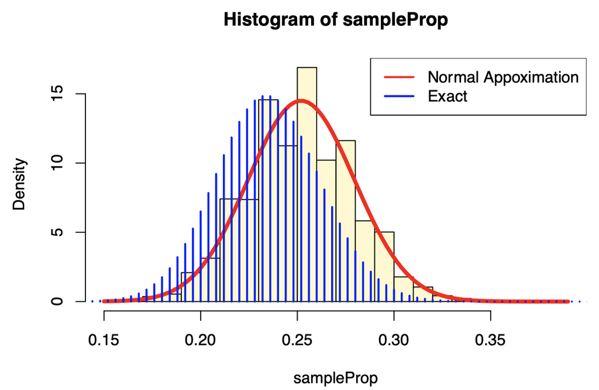

```r
B <- 10000
n <- length(manhattanSamp)
sampleProp <- replicate(B, {
    x <- sample(manhattanSamp, size = n, replace = TRUE)
    mean(x)
})

hist(sampleProp, probability = TRUE, breaks=30, col="lemonchiffon")
curve(dnorm(x, mean = mean(manhattanSamp), sd = sd(manhattanSamp)/sqrt(n)), add=TRUE, col=2, lwd=4)
lines((0:250)/250,250*dbinom(0:250,250, 0.235), type="h", lwd=2, col=4)
legend("topright", c("Normal Appoximation", "Exact"), lty=1, col=c(2,4), lwd=2)
```

#### 2.2 Bootstrap quantiles: Percentile Method

- Since the bootstrap allows us to approximate the whole sampling distribution of the estimator, we can also compute the quantiles to construct a confidence interval for the mean.
- `R`:

```r
quantile(sampleProp, c(0.025, 0.975))
```

```
##      2.5%     97.5%
## 0.2064321 0.3167708
```

- This is called the **percentile method**.
- According to the percentile method, the 95% confidence interval is 0.2064321 to 0.3167708.

### 3. Properties of the bootstrap distribution

#### 3.1 Center of the bootstrap distribution

- The center of the bootstrap distribution is **NOT** an accurate approximation of the center of the sampling distribution.
  - The bootstrap distribution of $\hat{\theta}$ is centered around the observed value $\hat{\theta}$ not around $\theta$.
- Hence, the bootstrap procedure cannot be used to get better parameter estimates.

#### 3.2 Variance and bias

The variance of the bootstrap distribution is a good approximation of the variance of the sampling distribution.

- The bias of the bootstrap estimates reflect the bias of the estimator.
- **The bootstrap is a procedure that can be used to qunatify the performance of estimators.**
- Bootstrap을 통해서 estimators(모수추정치들)의 성능(얼마나 좋은/정확한 추정인지)을 평가할 수 있음

#### 3.3 Example: Computing the MSE of an estimator

- The Mean Squared Error (MSE) of an estimator is:

$$M S E[\hat{\theta}]=E\left[(\hat{\theta}-\theta)^{2}\right]=\operatorname{Var}(\hat{\theta})+\operatorname{Bias}(\hat{\theta})^{2}$$

- We can use the bootstrap to estimate the MSE by substituting the original estimate $\hat{\theta}$ for $\theta$ and the bootstrap estimates $\hat{\theta}*$ for $\hat{\theta}$.

$$\widehat{M S E}[\hat{\theta}]=\frac{1}{B} \sum_{b=1}^{B}\left(\hat{\theta}^{*}-\hat{\theta}\right)^{2}=\operatorname{Var}\left(\hat{\theta}^{*}\right)+\operatorname{Bias}\left(\hat{\theta}^{*}\right)^{2}$$

- `R` to compute an estimate of the MSE for a bootstrap sample proportion.

```r
# MSE
sum((sampleProp - mean(manhattanSamp))^2)/B
```

```
## [1] 0.0007955637
```

> The estimate of the MSE for a bootstrap sample proportion is 7.9556373^{-4}. So an estimate of the MSE for a bootstrap sample proportion is 0.001. The corresponding bias of the bootstrap estimator (to three decimal places) is 0.

#### 3.4 Asymptotic vs Bootstrap confidence interval

- For estimating a population proportion, we have seen two ways.
  - <1> the normal distribution is a good approximation of the sampling distribution of $P$ when $n$, $n \pi$, $n(1-\pi)$ is large
  - <2> bootstrapping
- Note that **both are approximations**!
  - There is no fixed rule to choose between the two methods, but rather one needs to know the situations in which one works better than the other.
    - (symmetric, unimodal distribution) the normal approximation works better than the bootstrap.
    - (asymmetric, bimodal distribution) the bootstrap may be a better alternative than the normal approximation.
  - When $n$ is small, both methods do not work well.
    - When $n$ is small, use the **exact rescaled binomial distribution**.

### 4. Accuracy of the Bootstrap

#### 4.1 Random sampling

- The bootstrap principle involves drawing n observations from the original sample with replacement.
- In small samples, we could create all possible resamplings, but even for moderate $n$, this is unfeasible.
- For $n$ = 10 and $n$ = 20 the number of possible samples are:

```r
n <- 10
(ps <- choose(2 * n -1, n))
```

```
## [1] 92378
```

> In case of $n$=10, there are 9.2378^{4} possible samples.

```r
n <- 20
(ps <- choose(2 * n -1, n))
```

```
## [1] 68923264410
```

#### 4.2 Accuracy of bootstrap distributions

- <1> How accurate is the theoretical bootstrap?
- <2> How accurately does the Monte Carlo implementation approximate the theoretical bootstrap?
- Can improve the accuracy in <2> by **increasing the number of bootstrap samples**.
- However, there are situations in which the theoretical bootstrap distribution is **NOT** accurate.

#### 4.3 Sample proportion: large sample size

- In case for which we know the sampling distribution of the population proportion,
  - Consider $Y$~$B(n, \pi)$, then
  - we know that the sample proportion, $P$, is a rescaled binomial with mena $\pi$.
- `R`: How the bootstrap distribution approximates the true distribution with a large sample size, $n$=300 and a population proportion of $\pi$=0.5.

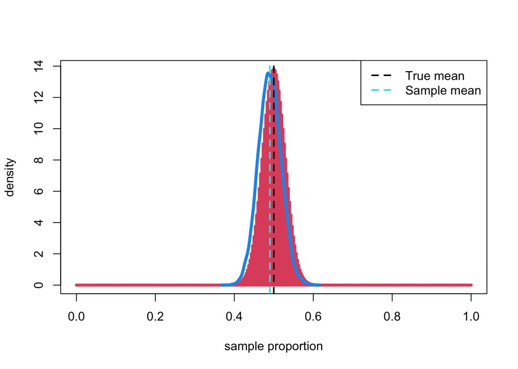

```r
n <- 300
# Using the same original sample
y <- rbinom(300, 1, 0.5)
B <- 10000
boot <- replicate(B, {
    s <- sample(y, size = n, replace = TRUE)
    # Using the original sample
    mean(s)
})

plot((0:300)/300,300*dbinom(0:300,300, 0.5), type="h", col = 2, lwd=4, xlab="sample proportion", ylab="density")
lines(density(boot), col=4, lwd=4)
abline(v = 0.5, lwd = 2, col = 1, lty = 2)
abline(v = mean(y), lwd = 2, lty = 2, col=5)
legend("topright", c("True mean", "Sample mean"), lty=2, col=c(1,5), lwd=2)
```

- The bootstrap distribution is not an accurate approximation of the center of the distribution.
- However, it is accurate at approximating its **spread**.
  - The spread (measured by the standard deviation) of the bootstrapped distribution is 0.029 and the corresponding value in the sample is 0.029.

#### 4.4 Sample mean: large sample size

- <1> Using the original sample
  - the accuracy related to point 2 above is pretty good.

```r
n <- 300
# Using the original sample
y <- rbinom(250, 1, 0.5)
B <- 10000

boot <- replicate(10, {
    replicate(B, {
        s <- sample(y, size = n, replace = TRUE)
        # Using the original sample
        mean(s)
    })
})
```

- The standard deviation of each of the 10 different bootstrap sampling distribution is :

```r
(sds <- apply(boot, 2, sd))
```

```
##  [1] 0.02939144 0.02890283 0.02882894 0.02890785 0.02866845 0.02900223
##  [7] 0.02870043 0.02848080 0.02874674 0.02896233
```

```r
n <- 300
B <- 10000

boot2 <- replicate(10, {
    # With different samples for each bootstrap
    y <- rbinom(n, 1, 0.5)
    replicate(B, {
        s <- sample(y, size = n, replace = TRUE)
        mean(s)
    })
})
```

- And the standard deviations of each of the 10 bootstrapped samples are:

```r
(sds2 <- apply(boot2, 2, sd))
```

```
##  [1] 0.02862964 0.02832271 0.02899045 0.02888168 0.02848900 0.02901158
##  [7] 0.02847996 0.02854243 0.02886581 0.02898566
```

- The ratio of the variances: **0.957**
  - (Variance of the 10 standard deviations of the bootstrapped samples from the same original sample) vs.
  - (Variance of the standard deviations of bootstrapped samples each from a different original sample)
- 0.957 which is less than one, it shows that the **variability in each sample is more than that of the bootstrapped sample from the original sample.**

#### 4.5 Sample mean: samll sample size

- In case $n$=5,

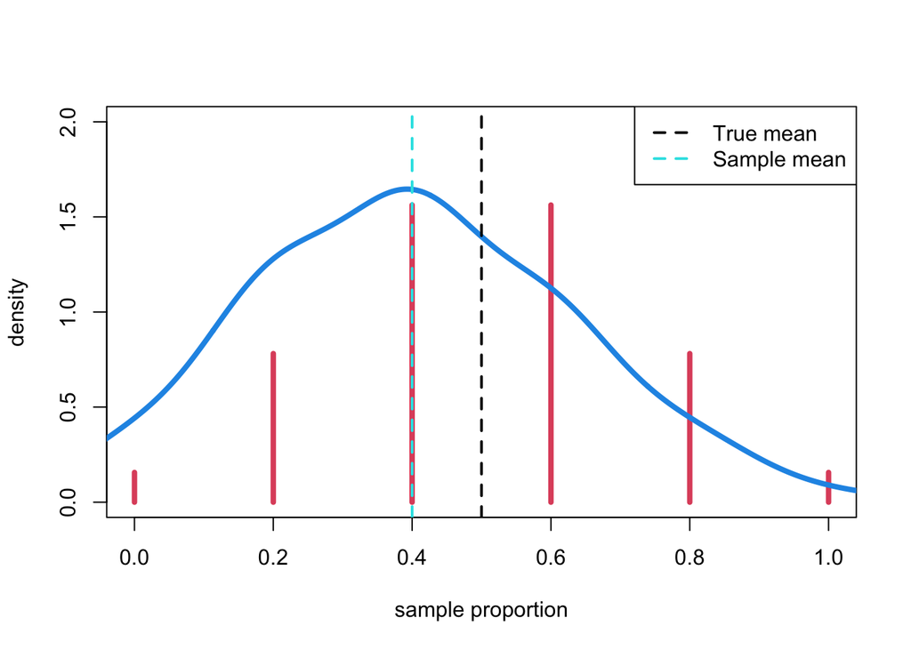

```r
n <- 5
y <- rbinom(n, 1, 0.5)
B <- 10000

boot <- replicate(B, {
    s <- sample(y, size = n, replace = TRUE)
    mean(s)
})

plot((0:5)/5,5*dbinom(0:5,5, 0.5), type="h", col = 2, lwd=4, ylim = c(0, 2), xlab="sample proportion", ylab="density")
lines(density(boot, bw=.1), col=4, lwd=4)
abline(v = 0.5, lwd = 2, col = 1, lty = 2)
abline(v = mean(y), lwd = 2, lty = 2, col=5)
legend("topright", c("True mean", "Sample mean"), lty=2, col=c(1,5), lwd=2)
```

```r
n <- 5
y <- rbinom(5, 1, 0.5)
B <- 10000

boot <- replicate(10, {
    replicate(B, {
        s <- sample(y, size = n, replace = TRUE)
        mean(s)
    })
})

(sds <- apply(boot, 2, sd))
```

```
##  [1] 0.1797592 0.1802509 0.1765080 0.1771508 0.1775471 0.1764528 0.1781882
##  [8] 0.1792257 0.1768745 0.1791327
```

- If we repeat the procedure with different original samples, we see that the accuracy related to point 1 above is now worse.

> **Takeaway**
> - The accuracy of the theoretical bootstrap depends on the original sample size n, while the accuracy of the Monte Carlo procedure depends on the number of bootstrap samples B.
- `R`: 10 bootstrapped sampling distributions, each from a diﬀerent original sample

```r
n <- 5
B <- 10000

boot2 <- replicate(10, {
    y <- rbinom(n, 1, 0.5)
    replicate(B, {
        s <- sample(y, size = n, replace = TRUE)
        mean(s)
    })
})
```

- The ratio of the variances: **0.018**
  - (Variance of the 10 standard deviations of the bootstrapped samples from the same original sample) vs.
  - (Variance of the standard deviations of bootstrapped samples each from a different original sample)
- 0.018 which is less than one, it shows that the **variability in each sample is more than that of the bootstrapped sample from the original sample.**

#### 4.6 How many bootstrap samples are needed?

- In general, $B=10000$ bootstrap samples lead to good accuracy
  - but there may be reasons to draw more or less samples, depending on the problem and on the objective of the study.
- Most of the time, **the main limiting facotr is the size of the original sample**, not the number of bootstrap samples.
- In case $B$=100,

```r
n <- 250
y <- rbinom(n, 1, 0.5)
B <- 100

boot <- replicate(10, {
    replicate(B, {
        s <- sample(y, size = n, replace = TRUE)
        mean(s)
    })
})

(sds <- apply(boot, 2, sd))
```

```
##  [1] 0.02714180 0.03274526 0.03173028 0.02934465 0.03164171 0.03434452
##  [7] 0.03337878 0.03386247 0.03464510 0.03317663
```

### 5. Useful `R` packages

- `boot` package is a gneral purpose package for all different types of the bootstrap
- `slipper` package is designed to work with the bootstrap in a `tidyverse` pipeline

#### 5.1 `boot` package

- reuqires three arguments:
  - the original sample
  - a function to compute the statistics
  - number of bootstrap samples

```r
library(boot)
n <- 300
x <- rbinom(n, 1, 0.5)

bootProp <- function(x, idx)
    {
    return(c(mean(x[idx]), var(x[idx])))
}

(bootObj <- boot(x, bootProp, 10000))
```

```
##
## ORDINARY NONPARAMETRIC BOOTSTRAP
##
##
## Call:
## boot(data = x, statistic = bootProp, R = 10000)
##
##
## Bootstrap Statistics :
##      original        bias    std. error
## t1* 0.4900000  0.0005286667 0.029059603
## t2* 0.2507358 -0.0008368718 0.001320175
```

- Confidence interval:

```r
boot.ci(bootObj, type = 'all')
```

```
## BOOTSTRAP CONFIDENCE INTERVAL CALCULATIONS
## Based on 10000 bootstrap replicates
##
## CALL :
## boot.ci(boot.out = bootObj, type = "all")
##
## Intervals :
## Level      Normal              Basic             Studentized
## 95%   ( 0.4325,  0.5464 )   ( 0.4333,  0.5467 )   ( 0.4331,  0.5472 )
##
## Level     Percentile            BCa
## 95%   ( 0.4333,  0.5467 )   ( 0.4300,  0.5433 )
## Calculations and Intervals on Original Scale
```

#### 5.2 Example

The question is whether the there is evidence that the age distribution of Manhattan residents diﬀers from that of the general US residents. We know that the $\pi$=0.35 for US residents. The manhattanSamp contains a random sample of Manhattan residents (it is truly a realistic representation of the Manhattan residents). We will now use boot to generate a percentile confidence interval for the population proportion based on a bootstrapped distribution of our sample.

```r
bootProp <- function(x, idx) {
    return(mean(x[idx]))
}

bootManhattanObj <- boot(manhattanSamp, bootProp, 10000)
boot.ci(bootManhattanObj, type = 'all')
```

```
## BOOTSTRAP CONFIDENCE INTERVAL CALCULATIONS
## Based on 10000 bootstrap replicates
##
## CALL :
## boot.ci(boot.out = bootManhattanObj, type = "all")
##
## Intervals :
## Level      Normal              Basic
## 95%   ( 0.2064,  0.3172 )   ( 0.2068,  0.3174 )
##
## Level     Percentile            BCa
## 95%   ( 0.2065,  0.3170 )   ( 0.2060,  0.3166 )
## Calculations and Intervals on Original Scale
```

> - The 95% confidence interval is 0.206 to 0.317.
> - Since the 95% bootstrap confidence interval does not contain 0.35, there is evidence that the age distribution of Manhattan residents differs from the general population of US residents.
> - It appears as though there is a lower proportion of Manhattan residents who are under 25 years old.

< Back to Syllabus